# Trabajo Fundamentos Matemáticos

*Ana Blasi, Mónica De Santos, Ana Elósegui*

En este trabajo se quiere estudiar un dataset que contiene los datos de varias campañas de marketing realizadas a clientes de un supermercado. En total se han realizado 6 campañas diferentes y se quiere analizar si existe relación entre su aceptación y las características de los clientes, sobre los cuales se ha recopilado información sobre su estado, su estilo de vida y los gastos en varios productos de los clientes. Este dataset se ha obtenido de la siguiente página, https://www.kaggle.com/rodsaldanha/arketing-campaign?select=marketing_campaign.csv, la cual también incluye la explicación de cada variable incluida en el análisis.

## Preliminares y carga de datos

```r
library(tidyverse)
library(ggplot2)
library(ggmosaic)
library(haven)
library(kernlab)
library(nortest)
library(corrplot)
library(GGally)
library(gridExtra)
library(grid)
```

```r
datos <- read.csv("./marketing_campaign.csv", sep = ";")
```

## Análisis exploratorio

Se imprimen las primeras filas del dataset con el que se va a trabajar para poder observar las variables y sus características.

```r
datos <- as_tibble(datos)
head(datos, 10)
```

```
## # A tibble: 10 × 29
##       ID Year_Birth Education  Marital_Status Income Kidhome Teenhome Dt_Customer
##    <int>      <int> <fct>      <fct>           <int>   <int>    <int> <fct>
##  1  5524       1957 Graduation Single          58138       0        0 2012-09-04
##  2  2174       1954 Graduation Single          46344       1        1 2014-03-08
##  3  4141       1965 Graduation Together        71613       0        0 2013-08-21
##  4  6182       1984 Graduation Together        26646       1        0 2014-02-10
##  5  5324       1981 PhD        Married         58293       1        0 2014-01-19
##  6  7446       1967 Master     Together        62513       0        1 2013-09-09
##  7   965       1971 Graduation Divorced        55635       0        1 2012-11-13
##  8  6177       1985 PhD        Married         33454       1        0 2013-05-08
##  9  4855       1974 PhD        Together        30351       1        0 2013-06-06
## 10  5899       1950 PhD        Together         5648       1        1 2014-03-13
## # … with 21 more variables: Recency <int>, MntWines <int>, MntFruits <int>,
## #   MntMeatProducts <int>, MntFishProducts <int>, MntSweetProducts <int>,
## #   MntGoldProds <int>, NumDealsPurchases <int>, NumWebPurchases <int>,
## #   NumCatalogPurchases <int>, NumStorePurchases <int>,
## #   NumWebVisitsMonth <int>, AcceptedCmp3 <int>, AcceptedCmp4 <int>,
## #   AcceptedCmp5 <int>, AcceptedCmp1 <int>, AcceptedCmp2 <int>, Complain <int>,
## #   Z_CostContact <int>, Z_Revenue <int>, Response <int>
```

Se va a trabajar con 29 variables y 2240 observaciones.

```r
dim(datos)
```

```
## [1] 2240   29
```

Se comprueba si hay datos nulos en el dataset para borrarlos si así fuera.

```r
any(is.na(datos))
```

```
## [1] TRUE
```

```r
colSums(is.na(datos))
```

```
##                  ID          Year_Birth           Education      Marital_Status
##                   0                   0                   0                   0
##              Income             Kidhome            Teenhome         Dt_Customer
##                  24                   0                   0                   0
##             Recency            MntWines           MntFruits     MntMeatProducts
##                   0                   0                   0                   0
##     MntFishProducts    MntSweetProducts        MntGoldProds   NumDealsPurchases
##                   0                   0                   0                   0
##     NumWebPurchases NumCatalogPurchases   NumStorePurchases   NumWebVisitsMonth
##                   0                   0                   0                   0
##        AcceptedCmp3        AcceptedCmp4        AcceptedCmp5        AcceptedCmp1
##                   0                   0                   0                   0
##        AcceptedCmp2            Complain       Z_CostContact           Z_Revenue
##                   0                   0                   0                   0
##            Response
##                   0
```

```r
datos = na.omit(datos)
dim(datos)
```

```
## [1] 2216   29
```

Además, para facilitar la exploración se cambia el nombre de la columna “Response” que corresponde a la última campaña, la sexta de todas las realizadas. Por otro lado se crea una nueva, llamada “Acceptance”, que resumen el total de campañas aceptadas por cada cliente. Además se reordenan las columnas para tener en primer lugar el resultado de la aceptación de las campañas.

```r
colnames(datos)[29] = "AcceptedCmp6"
datos = datos %>%
  mutate(Acceptance = AcceptedCmp1 + AcceptedCmp2 + AcceptedCmp3 + AcceptedCmp4 + AcceptedCmp5 + AcceptedCmp6)
datos = datos [, c(1, 24, 25, 21, 22, 23, 29, 30, 2:20, 26:28)]
head(datos, 10)
```

```
## # A tibble: 10 × 30
##       ID AcceptedCmp1 AcceptedCmp2 AcceptedCmp3 AcceptedCmp4 AcceptedCmp5
##    <int>        <int>        <int>        <int>        <int>        <int>
##  1  5524            0            0            0            0            0
##  2  2174            0            0            0            0            0
##  3  4141            0            0            0            0            0
##  4  6182            0            0            0            0            0
##  5  5324            0            0            0            0            0
##  6  7446            0            0            0            0            0
##  7   965            0            0            0            0            0
##  8  6177            0            0            0            0            0
##  9  4855            0            0            0            0            0
## 10  5899            0            0            1            0            0
## # … with 24 more variables: AcceptedCmp6 <int>, Acceptance <int>,
## #   Year_Birth <int>, Education <fct>, Marital_Status <fct>, Income <int>,
## #   Kidhome <int>, Teenhome <int>, Dt_Customer <fct>, Recency <int>,
## #   MntWines <int>, MntFruits <int>, MntMeatProducts <int>,
## #   MntFishProducts <int>, MntSweetProducts <int>, MntGoldProds <int>,
## #   NumDealsPurchases <int>, NumWebPurchases <int>, NumCatalogPurchases <int>,
## #   NumStorePurchases <int>, NumWebVisitsMonth <int>, Complain <int>, …
```

A continuación se muestra un resumen general de las distintas variables.

```r
summary(datos)
```

```
##        ID         AcceptedCmp1      AcceptedCmp2      AcceptedCmp3
##  Min.   :    0   Min.   :0.00000   Min.   :0.00000   Min.   :0.00000
##  1st Qu.: 2815   1st Qu.:0.00000   1st Qu.:0.00000   1st Qu.:0.00000
##  Median : 5458   Median :0.00000   Median :0.00000   Median :0.00000
##  Mean   : 5588   Mean   :0.06408   Mean   :0.01354   Mean   :0.07356
##  3rd Qu.: 8422   3rd Qu.:0.00000   3rd Qu.:0.00000   3rd Qu.:0.00000
##  Max.   :11191   Max.   :1.00000   Max.   :1.00000   Max.   :1.00000
##
##   AcceptedCmp4      AcceptedCmp5     AcceptedCmp6      Acceptance
##  Min.   :0.00000   Min.   :0.0000   Min.   :0.0000   Min.   :0.0000
##  1st Qu.:0.00000   1st Qu.:0.0000   1st Qu.:0.0000   1st Qu.:0.0000
##  Median :0.00000   Median :0.0000   Median :0.0000   Median :0.0000
##  Mean   :0.07401   Mean   :0.0731   Mean   :0.1503   Mean   :0.4486
##  3rd Qu.:0.00000   3rd Qu.:0.0000   3rd Qu.:0.0000   3rd Qu.:1.0000
##  Max.   :1.00000   Max.   :1.0000   Max.   :1.0000   Max.   :5.0000
##
##    Year_Birth        Education     Marital_Status     Income
##  Min.   :1893   2n Cycle  : 200   Married :857    Min.   :  1730
##  1st Qu.:1959   Basic     :  54   Together:573    1st Qu.: 35303
##  Median :1970   Graduation:1116   Single  :471    Median : 51382
##  Mean   :1969   Master    : 365   Divorced:232    Mean   : 52247
##  3rd Qu.:1977   PhD       : 481   Widow   : 76    3rd Qu.: 68522
##  Max.   :1996                     Alone   :  3    Max.   :666666
##                                   (Other) :  4
##     Kidhome          Teenhome          Dt_Customer      Recency
##  Min.   :0.0000   Min.   :0.0000   2012-08-31:  12   Min.   : 0.00
##  1st Qu.:0.0000   1st Qu.:0.0000   2012-09-12:  11   1st Qu.:24.00
##  Median :0.0000   Median :0.0000   2013-02-14:  11   Median :49.00
##  Mean   :0.4418   Mean   :0.5054   2014-05-12:  11   Mean   :49.01
##  3rd Qu.:1.0000   3rd Qu.:1.0000   2013-08-20:  10   3rd Qu.:74.00
##  Max.   :2.0000   Max.   :2.0000   2014-05-22:  10   Max.   :99.00
##                                    (Other)   :2151
##     MntWines        MntFruits      MntMeatProducts  MntFishProducts
##  Min.   :   0.0   Min.   :  0.00   Min.   :   0.0   Min.   :  0.00
##  1st Qu.:  24.0   1st Qu.:  2.00   1st Qu.:  16.0   1st Qu.:  3.00
##  Median : 174.5   Median :  8.00   Median :  68.0   Median : 12.00
##  Mean   : 305.1   Mean   : 26.36   Mean   : 167.0   Mean   : 37.64
##  3rd Qu.: 505.0   3rd Qu.: 33.00   3rd Qu.: 232.2   3rd Qu.: 50.00
##  Max.   :1493.0   Max.   :199.00   Max.   :1725.0   Max.   :259.00
##
```

[output cut: 9 more lines]

```
##  Min.   : 0.000      Min.   : 0.000    Min.   : 0.000    Min.   :0.000000
##  1st Qu.: 0.000      1st Qu.: 3.000    1st Qu.: 3.000    1st Qu.:0.000000
##  Median : 2.000      Median : 5.000    Median : 6.000    Median :0.000000
##  Mean   : 2.671      Mean   : 5.801    Mean   : 5.319    Mean   :0.009477
##  3rd Qu.: 4.000      3rd Qu.: 8.000    3rd Qu.: 7.000    3rd Qu.:0.000000
##  Max.   :28.000      Max.   :13.000    Max.   :20.000    Max.   :1.000000
##
##  Z_CostContact   Z_Revenue
##  Min.   :3     Min.   :11
##  1st Qu.:3     1st Qu.:11
##  Median :3     Median :11
##  Mean   :3     Mean   :11
##  3rd Qu.:3     3rd Qu.:11
##  Max.   :3     Max.   :11
##
```

De la información obtenida cabe destacar que el máximo de “Acceptance” es 5 lo que implica que hay consumidores que aceptan la campaña en más de una ocasión (más adelante se estudiará cuantas personas aceptan en cada campaña). Además, el producto en el que más dinero se gasta es en el vino, por lo que luego se estudiará esta variable en detalle.

Se muestran el número total de campañas aceptadas por los clientes.

```r
datos %>%
  count(Acceptance)
```

```
## # A tibble: 6 × 2
##   Acceptance     n
##        <int> <int>
## 1          0  1611
## 2          1   369
## 3          2   139
## 4          3    51
## 5          4    36
## 6          5    10
```

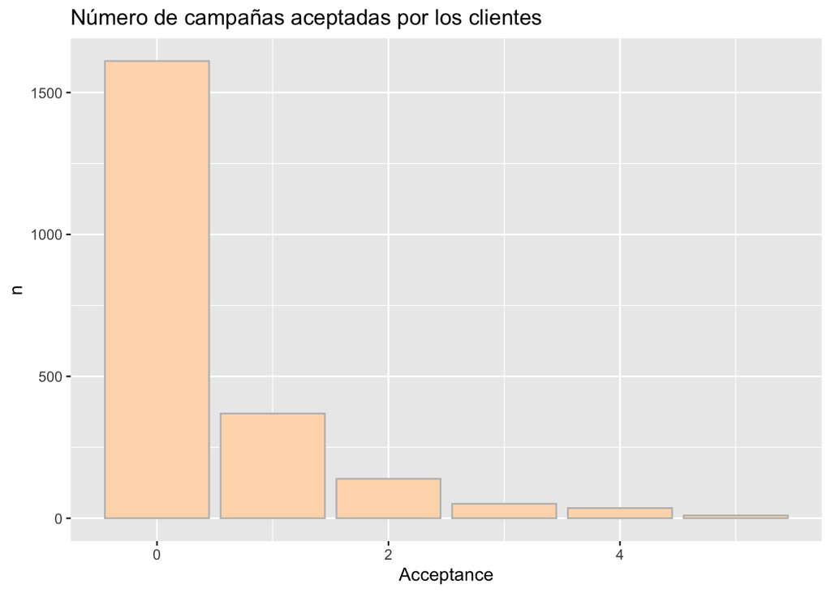

```r
datos %>%
  count(Acceptance) %>%
  ggplot(mapping = aes(x = Acceptance, y = n)) +
  geom_col(fill="peachpuff", color="grey") +
  ggtitle("Número de campañas aceptadas por los clientes")
```

La mayoría de los clientes no acepta ninguna de las promociones ofrecidas (0.727), y entre los que lo hacen, el número de ocasiones en las que las aceptan va disminuyendo.

También interesa conocer la distribución general de las variables de estudio para el tratamiento futuro de estas.

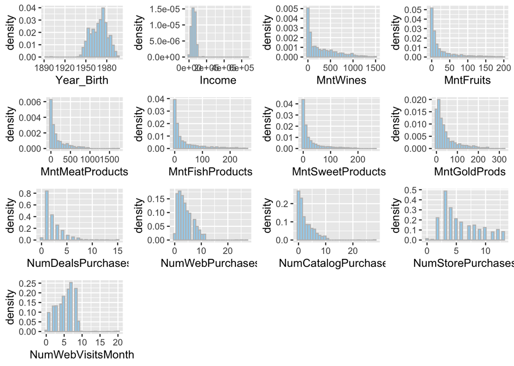

```r
g1 = datos %>%
  ggplot(aes(x = Year_Birth)) +
  geom_histogram(aes(y = stat(density)), fill= "lightskyblue2", color = "grey")
g2 = datos %>%
  ggplot(aes(x = Income)) +
  geom_histogram(aes(y = stat(density)), fill= "lightskyblue2", color = "grey")
g3 = datos %>%
  ggplot(aes(x = MntWines)) +
  geom_histogram(aes(y = stat(density)), fill= "lightskyblue2", color = "grey")
g4 = datos %>%
  ggplot(aes(x = MntFruits)) +
  geom_histogram(aes(y = stat(density)), fill= "lightskyblue2", color = "grey")
g5 = datos %>%
  ggplot(aes(x = MntMeatProducts)) +
  geom_histogram(aes(y = stat(density)), fill= "lightskyblue2", color = "grey")
g6 = datos %>%
  ggplot(aes(x = MntFishProducts)) +
  geom_histogram(aes(y = stat(density)), fill= "lightskyblue2", color = "grey")
g7 = datos %>%
  ggplot(aes(x = MntSweetProducts)) +
  geom_histogram(aes(y = stat(density)), fill= "lightskyblue2", color = "grey")
g8 = datos %>%
  ggplot(aes(x = MntGoldProds)) +
  geom_histogram(aes(y = stat(density)), fill= "lightskyblue2", color = "grey")
g9 = datos %>%
  ggplot(aes(x = NumDealsPurchases)) +
  geom_histogram(aes(y = stat(density)), fill= "lightskyblue2", color = "grey")
g10 = datos %>%
  ggplot(aes(x = NumWebPurchases)) +
  geom_histogram(aes(y = stat(density)), fill= "lightskyblue2", color = "grey")
g11 = datos %>%
  ggplot(aes(x = NumCatalogPurchases)) +
  geom_histogram(aes(y = stat(density)), fill= "lightskyblue2", color = "grey")
g12 = datos %>%
  ggplot(aes(x = NumStorePurchases)) +
  geom_histogram(aes(y = stat(density)), fill= "lightskyblue2", color = "grey")
g13 = datos %>%
  ggplot(aes(x = NumWebVisitsMonth)) +
  geom_histogram(aes(y = stat(density)), fill= "lightskyblue2", color = "grey")


grid.arrange(g1, g2, g3, g4, g5, g6, g7, g8, g9, g10, g11, g12, g13, ncol = 4)
```

Según lo que se puede observar en estos gráficos de las variables numéricas, la única que sigue una distribución aparentmente normal es “Year_Birth”. Se observa que las variables “MntFruits”, “MntMeatProducts”, “MntFishProducts”, “MntSweetProducts”, siguen una distribución aproximadamente exponencial.

Por último, para acabar con el análisis general se estudia la relación que existe entre las variables numéricas.

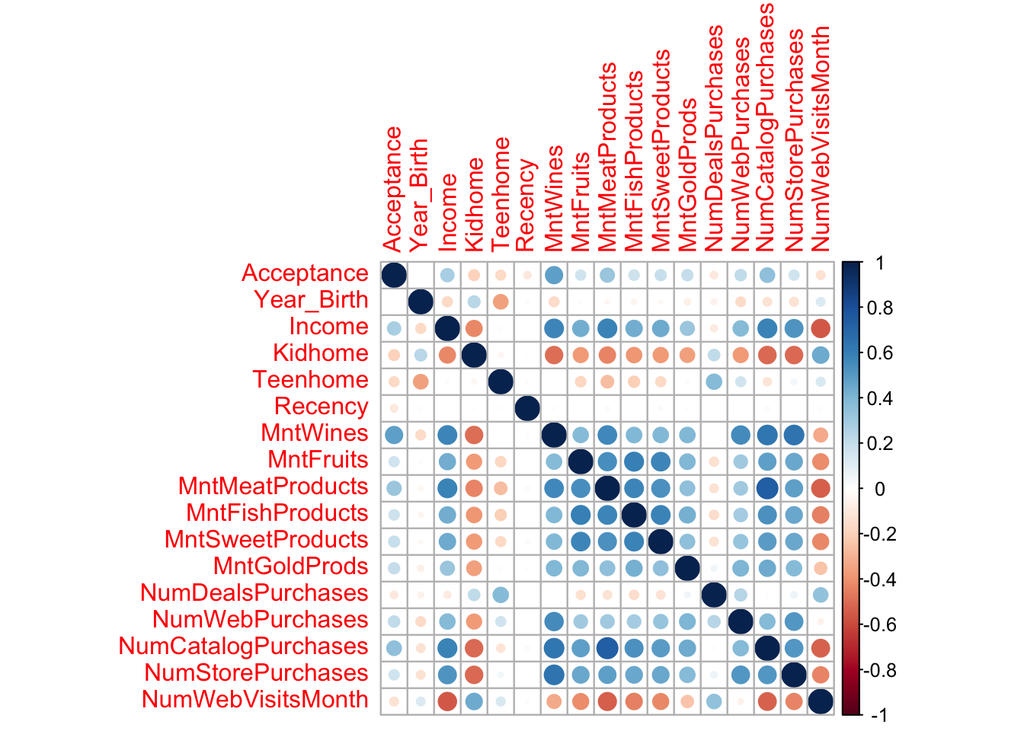

```r
C <- cor(datos[,c(8,9,12:14,16:27)])
corrplot::corrplot(C, method = "circle")
```

En este gráfico se puede ver que las variables que más correlacionadas linealmente están con “Acceptance”, son “MntWine” y “NumCatalogPurchases” por lo que se estudiarán por separado.

## Estudio en base a la aceptación

En este apartado se busca analizar las diferencias entre las personas que han aceptado la campaña al menos una vez y las que no. Para ello se crea una nueva columna, “Acceptance_si_no”, que lo indica. También, se factoriza dicha variable.

Primero, se ha decidido realizar otra matriz de correlación para contrastar los datos obtenidos en la anterior y comprobar las relaciones existentes ahora que se ha generado una variable clasificatoria según si cada cliente ha aceptado alguna de las campañas o no.

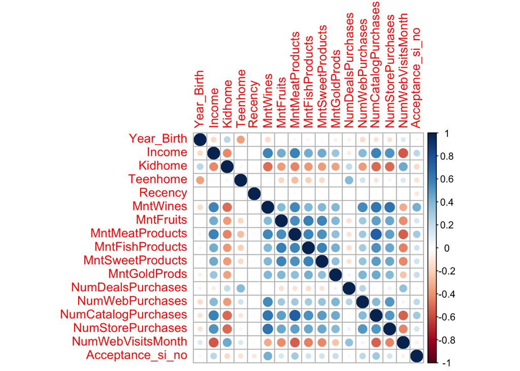

```r
datos_acceptance = datos %>%
  mutate(Acceptance_si_no = ifelse(Acceptance==0,0,1))
C <- cor(datos_acceptance[,c(9,12:14,16:27,31)])
corrplot::corrplot(C, method = "circle")
```

De esta matriz de correlación obtenida se puede afirmar, que igual que se había afirmado en el análisis general, las variables que más relación guardan con la variable clasificatoria “Accepance_si_no” son “MntWines” y “NumCatalogPurchases”. Además de estas dos variables también se van a analizar otras que se han considerado de interés.

Antes de comenzar con los análisis se factoriza la variable “Acceptance_si_no”.

```r
datos_acceptance = datos %>%
  mutate(Acceptance_si_no = ifelse(Acceptance==0,'NO','YES'))
datos_acceptance$Acceptance_si_no <- as_factor(datos_acceptance$Acceptance_si_no)
```

```r
datos_acceptance %>% select(ID, Acceptance_si_no) %>% head()
```

```
## # A tibble: 6 × 2
##      ID Acceptance_si_no
##   <int> <fct>
## 1  5524 YES
## 2  2174 NO
## 3  4141 NO
## 4  6182 NO
## 5  5324 NO
## 6  7446 NO
```

#### INGRESOS

Primero, se ha decidido analizar la variable Income y estudiar como afecta el salario del usuario a su compra. Se ha realizado un boxplot donde se podrá estudiar si hay una diferencia entre las diferentes medias de los Incomes según ha aceptado la campaña o no.

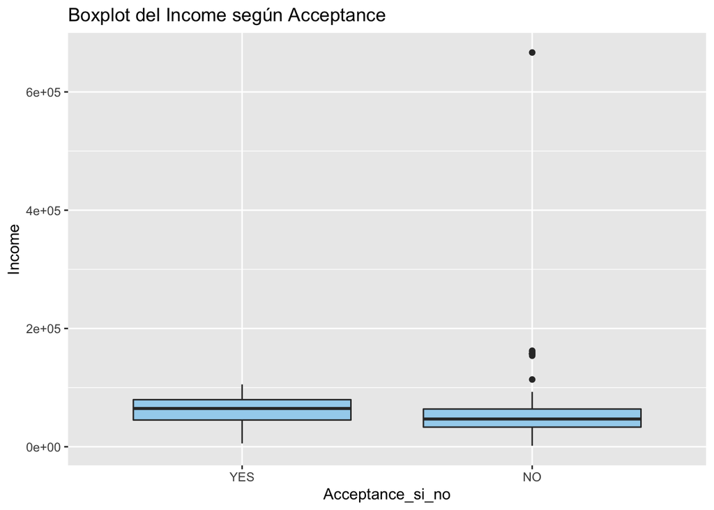

```r
ggplot(datos_acceptance)+
  geom_boxplot(aes(x=Acceptance_si_no,y=Income),fill='lightskyblue2') +
  ggtitle("Boxplot del Income según Acceptance")
```

En el anterior boxplot se observa la existencia de unos outliers. Para continuar con el estudio se ha decidido prescendir de ellos.

```r
datos_acceptance <- datos_acceptance %>%
  filter(Income<6e+5)
```

Al realizar el boxplot por segunda vez, se observa que al haber eliminado los outliers, se reduce la escala de Income y permite analizar el resultado con mayor claridad. Se aprecia como las personas que aceptan la campaña, almenos una vez, tienen un salario mayor que las que no la han aceptado.

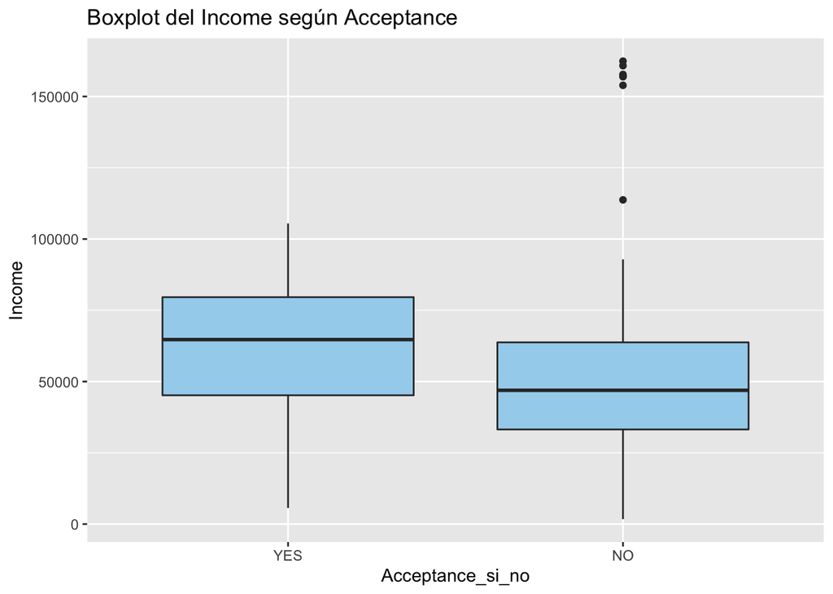

```r
ggplot(datos_acceptance)+
  geom_boxplot(aes(x=Acceptance_si_no, y=Income),fill='lightskyblue2') +
  ggtitle("Boxplot del Income según Acceptance")
```

Aun así, se ha querido comprobar si realmente existe una diferencia significativa entre las dos medias. Para ello, se ha decidido realizar un Two Sample T-test que estudia la igualdad de medias. Antes, se han creado las dos muestras segregando entre si aceptado y no.

```r
yes_income <- datos_acceptance %>%
  filter(Acceptance_si_no=="YES") %>%
  select(Income)
no_income <- datos_acceptance %>%
  filter(Acceptance_si_no=="NO") %>%
  select(Income)
```

Ahora, es el momento del análisis.

```
  Hipótesis nula es H0:μsi=μno

  Hipótesis alternativa es H1:μsi≠μno
```

```r
t.test(yes_income, no_income, # dos muestras
        alternative = "two.sided", # contraste bilateral
        paired = FALSE, # muestras independientes
        var.equal = TRUE )
```

```
##
##  Two Sample t-test
##
## data:  yes_income and no_income
## t = 13.652, df = 2213, p-value < 2.2e-16
## alternative hypothesis: true difference in means is not equal to 0
## 95 percent confidence interval:
##  11527.85 15395.28
## sample estimates:
## mean of x mean of y
##  61754.57  48293.00
```

Se ha obtenido el siguiente resultado:

- pvalor < 2.2e-16

Por lo tanto rechazamos la hipotesis nula, lo que significa que sí que hay una diferencia significativa entre las medias.Se confirma que las personas que sí que aceptan al menos una vez tienen significativamente un Income mayor que las que no aceptan.

#### EDAD

A continuación, se ha decidido estudiar como afecta la edad a la aceptación. Se ha realizado un boxplot.

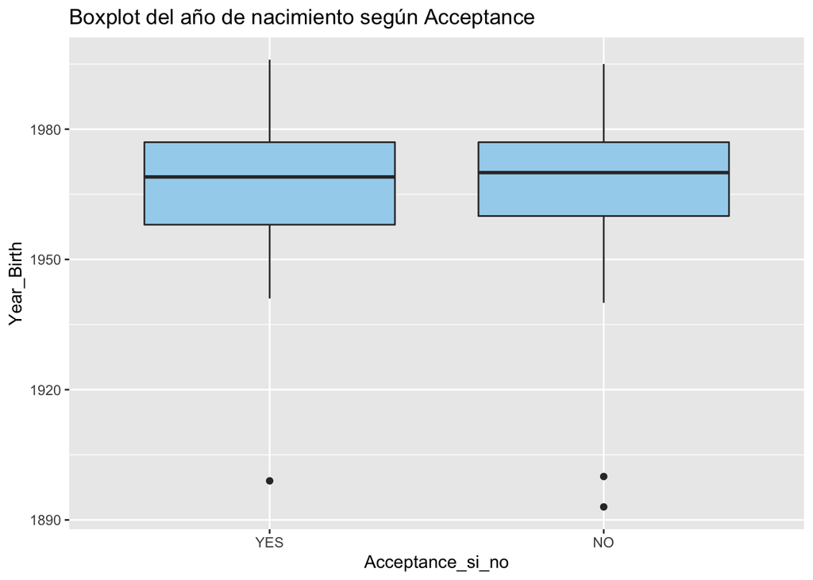

```r
ggplot(datos_acceptance)+
  geom_boxplot(aes(x=Acceptance_si_no,y=Year_Birth),fill='lightskyblue2') +
  ggtitle("Boxplot del año de nacimiento según Acceptance")
```

Se observan unos outliers y se ha decidido despreciarlos del dataset.

```r
datos_acceptance = datos_acceptance %>%
  filter(Year_Birth>1920)
```

Se vuelve a realizar el boxplot y se estudia el resultado. Se considera que no hay diferencia entre la media de edad de las personas que aceptan y las que no. Aun así, más adelante se realizará un análisis para estudiar la significatividad de la diferencia.

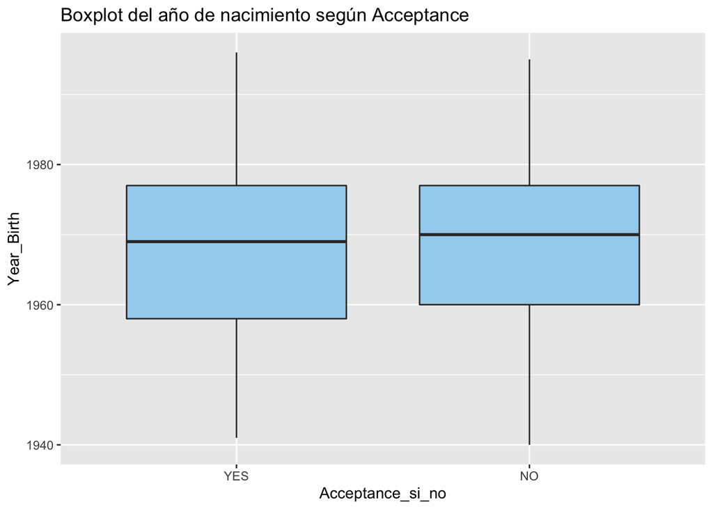

```r
ggplot(datos_acceptance)+
  geom_boxplot(aes(x=Acceptance_si_no,y=Year_Birth), fill='lightskyblue2') +
  ggtitle("Boxplot del año de nacimiento según Acceptance")
```

Primero, se crean las muestras que se utilizarán en el Two Sample T-test. Como en el apartado anterior, también se separa entre aceptado y no aceptado.

```r
yes_year_birth <- datos_acceptance %>%
  filter(Acceptance_si_no=="YES") %>%
  select(Year_Birth)
no_year_birth <- datos_acceptance %>%
  filter(Acceptance_si_no=="NO") %>%
  select(Year_Birth)
```

A continuación, se efectua el analisis.

```
  Hipótesis nula es H0:μsi=μno

  Hipótesis alternativa es H1:μsi≠μno
```

```r
t.test( yes_year_birth, no_year_birth, # dos muestras
        alternative = "two.sided", # contraste bilateral
        paired = FALSE, # muestras independientes
        var.equal = TRUE )
```

```
##
##  Two Sample t-test
##
## data:  yes_year_birth and no_year_birth
## t = -1.5211, df = 2210, p-value = 0.1284
## alternative hypothesis: true difference in means is not equal to 0
## 95 percent confidence interval:
##  -1.9439610  0.2456315
## sample estimates:
## mean of x mean of y
##  1968.296  1969.146
```

Se obtiene el siguiente resultado:

- p-value > 0.05

Como ya se había comentado antes, no se rechaza la hipotesis nula y, por lo tanto, no se puede decir que, estadísticamente hablando, haya una diferencia significativa entre la edad media de aquellos que aceptan o no alguna campaña.

#### ESTADO CIVIL

La siguiente variable que se estudiará es el Marital Status. Según el siguiente gráfico, no parece que haya una diferencia significativa en cuanto al estado, para aceptar la campaña o no, ya que las proporciones de esta variable en ambos casos son practicamente iguales; lo cual significa, que esta variable no sería importante a la hora de saber si una persona va a aceptar la campaña o no.

```r
datos_acceptance %>%
  group_by(Acceptance_si_no) %>%
  count(Marital_Status)
```

```
## # A tibble: 16 × 3
## # Groups:   Acceptance_si_no [2]
##    Acceptance_si_no Marital_Status     n
##    <fct>            <fct>          <int>
##  1 YES              Absurd             1
##  2 YES              Alone              1
##  3 YES              Divorced          69
##  4 YES              Married          216
##  5 YES              Single           147
##  6 YES              Together         143
##  7 YES              Widow             26
##  8 YES              YOLO               1
##  9 NO               Absurd             1
## 10 NO               Alone              2
## 11 NO               Divorced         162
## 12 NO               Married          641
## 13 NO               Single           323
## 14 NO               Together         428
## 15 NO               Widow             50
## 16 NO               YOLO               1
```

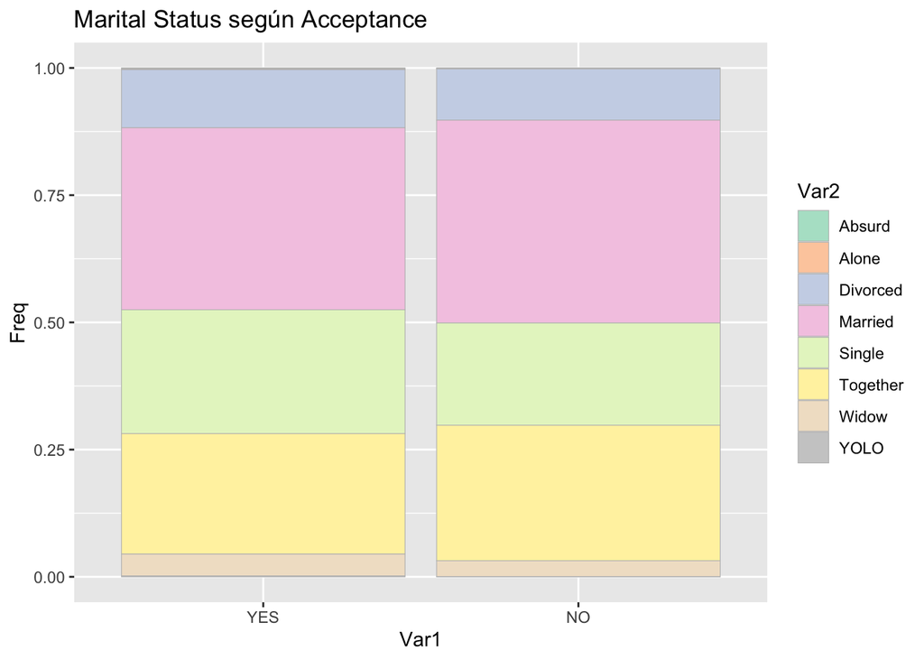

```r
tabla_marital_status <- table(datos_acceptance$Acceptance_si_no,datos_acceptance$Marital_Status)
prop_marital = as.data.frame(prop.table(tabla_marital_status,margin = 1))

ggplot(prop_marital,aes(x=Var1,y=Freq,fill=Var2)) + geom_col(color='grey', size=0.2) +
  scale_fill_brewer(palette="Pastel2") +
  ggtitle("Marital Status según Acceptance")
```

Tablas de probabilidades

```r
tabla_prop <- prop.table(tabla_marital_status)
addmargins(tabla_prop)
```

```
##
##             Absurd        Alone     Divorced      Married       Single
##   YES 0.0004520796 0.0004520796 0.0311934901 0.0976491863 0.0664556962
##   NO  0.0004520796 0.0009041591 0.0732368897 0.2897830018 0.1460216998
##   Sum 0.0009041591 0.0013562387 0.1044303797 0.3874321881 0.2124773960
##
##           Together        Widow         YOLO          Sum
##   YES 0.0646473779 0.0117540687 0.0004520796 0.2730560579
##   NO  0.1934900542 0.0226039783 0.0004520796 0.7269439421
##   Sum 0.2581374322 0.0343580470 0.0009041591 1.0000000000
```

```r
tabla_prop_1 <- prop.table(tabla_marital_status,margin = 1)
addmargins(tabla_prop_1)
```

```
##
##             Absurd        Alone     Divorced      Married       Single
##   YES 0.0016556291 0.0016556291 0.1142384106 0.3576158940 0.2433774834
##   NO  0.0006218905 0.0012437811 0.1007462687 0.3986318408 0.2008706468
##   Sum 0.0022775197 0.0028994102 0.2149846793 0.7562477348 0.4442481302
##
##           Together        Widow         YOLO          Sum
##   YES 0.2367549669 0.0430463576 0.0016556291 1.0000000000
##   NO  0.2661691542 0.0310945274 0.0006218905 1.0000000000
##   Sum 0.5029241211 0.0741408850 0.0022775197 2.0000000000
```

```r
tabla_prop_2 <- prop.table(tabla_marital_status,margin = 2)
addmargins(tabla_prop_2)
```

```
##
##          Absurd     Alone  Divorced   Married    Single  Together     Widow
##   YES 0.5000000 0.3333333 0.2987013 0.2520420 0.3127660 0.2504378 0.3421053
##   NO  0.5000000 0.6666667 0.7012987 0.7479580 0.6872340 0.7495622 0.6578947
##   Sum 1.0000000 1.0000000 1.0000000 1.0000000 1.0000000 1.0000000 1.0000000
##
##            YOLO       Sum
##   YES 0.5000000 2.7893857
##   NO  0.5000000 5.2106143
##   Sum 1.0000000 8.0000000
```

#### EDUCATION

Se va a estudiar si la variable Education es significativa para saber si una persona aceptará la campaña o no. En el siguiente gráfico se muestra la proporción de las clases de educación de las personas, clasificado en si han aceptado la campaña o no. Se puede observar que las proporciones no difieren mucho las unas de las otras, en cuanto a YES y NO.

```r
datos_acceptance %>%
  group_by(Acceptance_si_no) %>%
  count(Education)
```

```
## # A tibble: 10 × 3
## # Groups:   Acceptance_si_no [2]
##    Acceptance_si_no Education      n
##    <fct>            <fct>      <int>
##  1 YES              2n Cycle      45
##  2 YES              Basic          7
##  3 YES              Graduation   296
##  4 YES              Master        99
##  5 YES              PhD          157
##  6 NO               2n Cycle     153
##  7 NO               Basic         47
##  8 NO               Graduation   819
##  9 NO               Master       266
## 10 NO               PhD          323
```

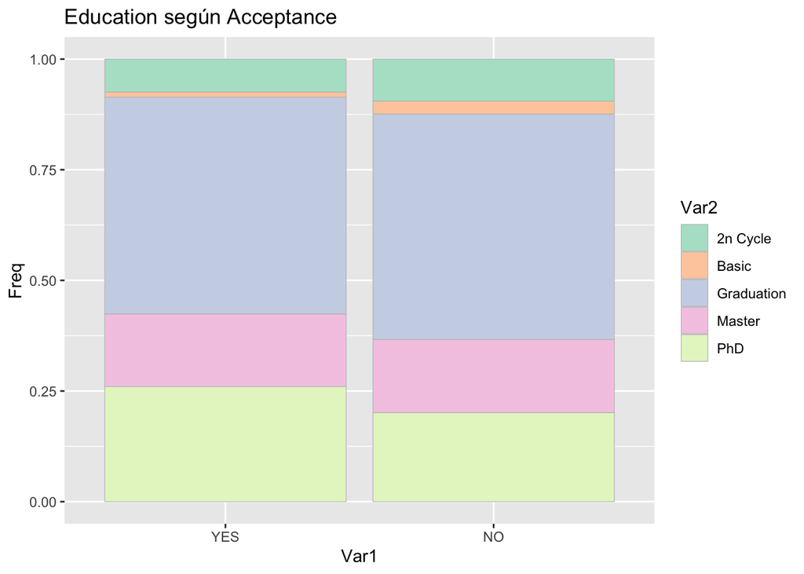

```r
tabla_education <- table(datos_acceptance$Acceptance_si_no,datos_acceptance$Education)
prop_education = as.data.frame(prop.table(tabla_education,margin = 1))

ggplot(prop_education,aes(x=Var1,y=Freq,fill=Var2)) + geom_col(color='grey', size=0.2) +
  scale_fill_brewer(palette="Pastel2") +
  ggtitle("Education según Acceptance")
```

Tabla de probabilidades

```r
tabla_prop <- prop.table(tabla_education)
addmargins(tabla_prop)
```

```
##
##          2n Cycle       Basic  Graduation      Master         PhD         Sum
##   YES 0.020343580 0.003164557 0.133815552 0.044755877 0.070976492 0.273056058
##   NO  0.069168174 0.021247740 0.370253165 0.120253165 0.146021700 0.726943942
##   Sum 0.089511754 0.024412297 0.504068716 0.165009042 0.216998192 1.000000000
```

```r
tabla_prop_1 <- prop.table(tabla_education,margin = 1)
addmargins(tabla_prop_1)
```

```
##
##         2n Cycle      Basic Graduation     Master        PhD        Sum
##   YES 0.07450331 0.01158940 0.49006623 0.16390728 0.25993377 1.00000000
##   NO  0.09514925 0.02922886 0.50932836 0.16542289 0.20087065 1.00000000
##   Sum 0.16965256 0.04081826 0.99939458 0.32933017 0.46080442 2.00000000
```

```r
tabla_prop_2 <- prop.table(tabla_education,margin = 2)
addmargins(tabla_prop_2)
```

```
##
##        2n Cycle     Basic Graduation    Master       PhD       Sum
##   YES 0.2272727 0.1296296  0.2654709 0.2712329 0.3270833 1.2206894
##   NO  0.7727273 0.8703704  0.7345291 0.7287671 0.6729167 3.7793106
##   Sum 1.0000000 1.0000000  1.0000000 1.0000000 1.0000000 5.0000000
```

De este gráfico se puede decir que las personas que tienen un nivel básico de educación tienden a no aceptar las campañas realizadas mientras que aquellos con un nivel superior de educación, sobre todo los que tienen un master o un doctorado tienden a aceptar más las promociones ofrecidas.

#### CATÁLOGO

A continuación se va a estudiar la variable de aceptación mediante las compras por catálogo. La variable “Catalog_si_no” es una transformación de la variable “NumCatalogPurchases”, la cual era numérica y representaba el número de compras en catálogo por cada persona; la nueva variable es categórica e indica si esa persona ha comprado nates por catálogo o no.

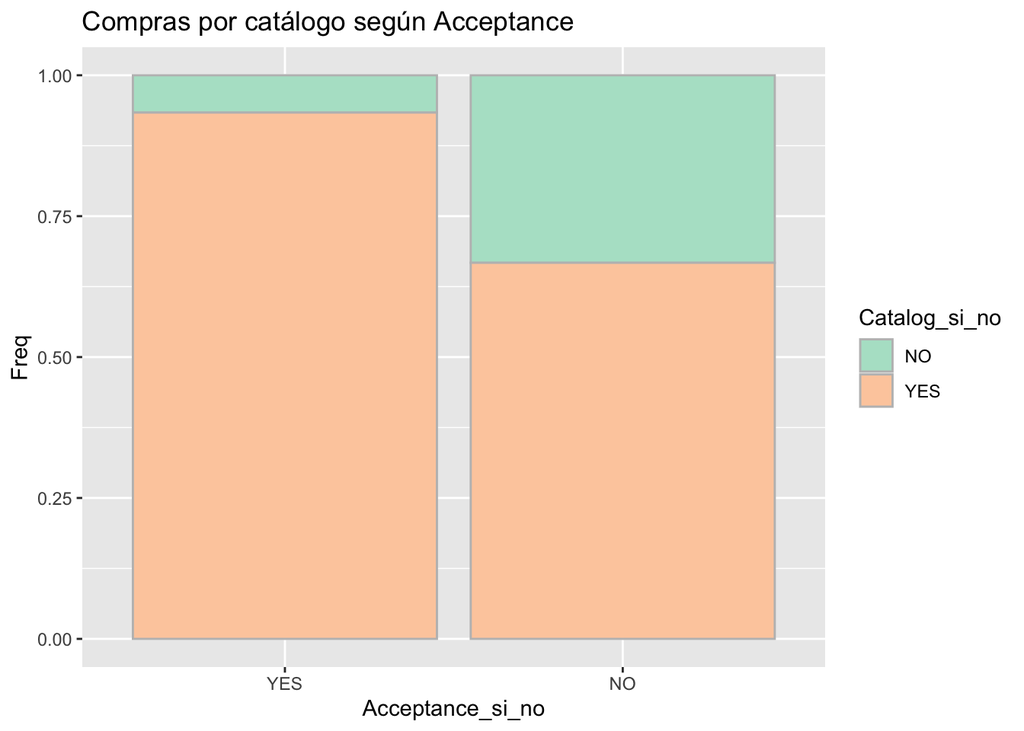

```r
datos_acceptance = datos_acceptance %>%
  mutate(Catalog_si_no = ifelse(NumCatalogPurchases==0, "NO", "YES"))

table_cat = table(datos_acceptance$Acceptance_si_no, datos_acceptance$Catalog_si_no)
propt_cat = as.data.frame(prop.table(table_cat, margin=1))

ggplot(propt_cat,aes(x=Var1,y=Freq,fill=Var2)) + geom_col(color="grey") +
  scale_fill_brewer(palette="Pastel2") +
  labs(x="Acceptance_si_no", fill="Catalog_si_no") +
  ggtitle("Compras por catálogo según Acceptance")
```

En el gráfico anterior se puede ver que las personas que compran mediante catálogo tienden a aceptar más las campañas de marketing.

#### WINE

La variable MntWine es la última variable que se estudiará en esta primera parte del proyecto. Primero, se ha decidido realizar un boxplot para visualizar si hay alguna diferencia significativa entre las diferentes medias.

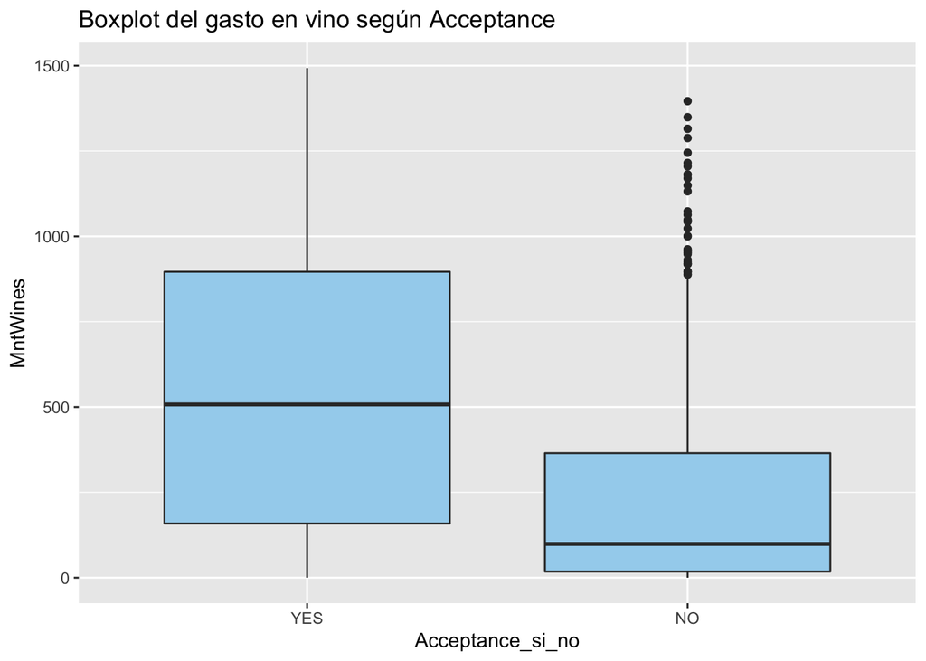

```r
ggplot(datos_acceptance) +
  geom_boxplot(aes(x=Acceptance_si_no, y=MntWines),fill='lightskyblue2') +
  ggtitle("Boxplot del gasto en vino según Acceptance")
```

Según el gráfico se acepta que las personas que han aceptado almenos una vez sí que compran más vino que las personas que no acepeptan. De ahí a que la variable MntWine no sigue una distribución normal no se ha podido realizar el analisis de two sample t-test.

Antes de seguir con la segunda parte del proyecto, se ha decidido analizar la variable wine con más profundidad. Se ha querido estudiar la compra de vino en los diferentes individuos. Se estudiará la relación de la cantidad de dinero que se compra de vino con los hijos que se tengan, con Marital Status y con la educación.